# Case Study 3 - Compressive Strength of Concrete

Joe Paturzo

4/1/2021

## Discovery and Motivations

**Introduction - Civil Engineering From The View Of an Aerospace Test Engineer**

On the surface, there does not appear to be much crossover between civil engineering and aerospace structural testing. That said, in the last 10 years as a test engineer, I have had to learn more civil engineering skills than I realized. Aerospace components are optimized to within a fraction of their usable life, often requiring thousands of man hours to design and make simple non-rotating components like brackets and mounts. That is how you end up with components that look like this:

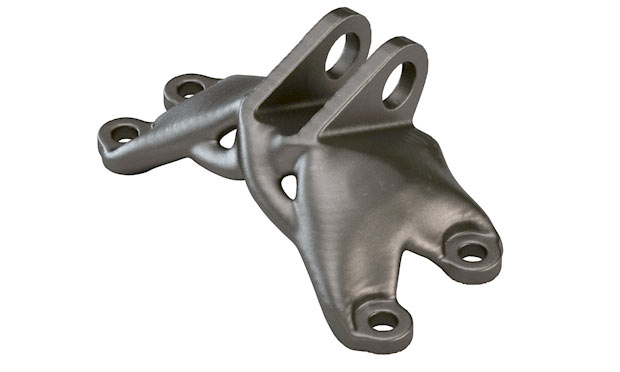

[**Topology Design Optimization**](https://www.digitalengineering247.com/article/topology-optimization-dmp-help-complete-design-challenge/)

But in the testing world, we somehow end up with parts that look like this (author of report for scale)

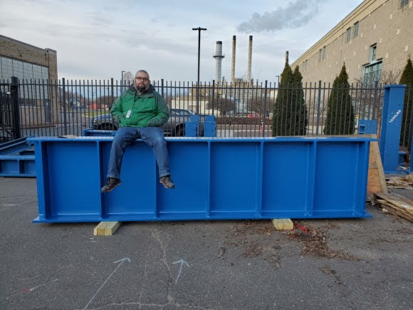

Where does the Civil aspect come in? Testing these structures require stiff and robust fixturing capable of imparting enormous loads. The amount of energy during a Fan Blade Out (FBO) event can be upwards of [**750 kJ**](https://apps.dtic.mil/dtic/tr/fulltext/u2/a045314.pdf). When it comes time to simulate the response forces generated by this energy, there are only 2 things you can count on: steel and concrete.

I am much more intimately familiar with steel, as that is an everyday design material. But when planning something like a new facility, concrete becomes a very interesting material to try and understand. Due to the time and cost involved in any construction project, being able to bring some basic knowledge of the subject is critical.

The dataset to be used was downloaded from [**Kaggle**](https://www.kaggle.com/maajdl/yeh-concret-data). It represents the ingredients list on the basis of kg per m3 and the resultant compressive strength in Megapascals.

I will be following the typical approach of single variate discovery, followed by multivariate analysis.

First, lets take a peak at the data to understand formatting and content.

| cement | slag | flyash | water | superplasticizer | coarseaggregate | fineaggregate | age | csMPa |
| --- | --- | --- | --- | --- | --- | --- | --- | --- |
| 540.0 | 0.0 | 0 | 162 | 2.5 | 1040 | 676 | 28 | 79.99 |
| 540.0 | 0.0 | 0 | 162 | 2.5 | 1055 | 676 | 28 | 61.89 |
| 332.5 | 142.5 | 0 | 228 | 0.0 | 932 | 594 | 270 | 40.27 |

All units for the concrete ingredients are in the units of $\ kg/m^3$. The age variable is the number of days the concrete has been allowed to cure. For a quick concrete primer, continue below. Its not critical to the operation of the application, so skip to the business problem statement if you want.

The [**cement.org FAQ page**](https://www.cement.org/cement-concrete/cement-and-concrete-basics-faqs) for concrete gives an excellent lesson in the basics of concrete. The thing to remember is, making concrete is very much like baking a cake. Deviation in recipe is often catastrophic, and fully understanding the materials at hand is critical.

1. Cement - This is the primary binding agent in concrete, and will undergo a chemical reaction when mixed with water.
2. Slag - This material is produced as a byproduct of iron processing in blast furnaces. It is a binding agent.
3. Flyash - Another binding agent, flyash is a byproduct of coal combustion.
4. Water - Water acts as a solvent for the binding agents, and aids in making a workable mixture
5. Superplasticizer - Performs several functions to the mix: retards reaction time, makes the mixture easier to work / spread, and reduces the amount of water required.
6. Aggregates - Fine and coarse aggregates act as the filler in the mixture. This is typically sand, gravel, stone, and increasingly recycled materials.

**Business Problem Statement**

Is it possible to estimate the compressive strength of concrete based on the material composition and aging time of a mix? This is a critical business issue for someone building a facility, or for the company providing the concrete. While not extremely expensive, concrete can be very time consuming to experimentally develop, as cure times can be up to one year before full strength is reached. Any modeling that can provide insight to the quality of the final product is enormously helpful.

## Data Prep

As provided, the data set appears complete and should not require any modifications to work with.

In order to visualize the sensitivities between ingredients, we’ll look at a simple correlation plot:

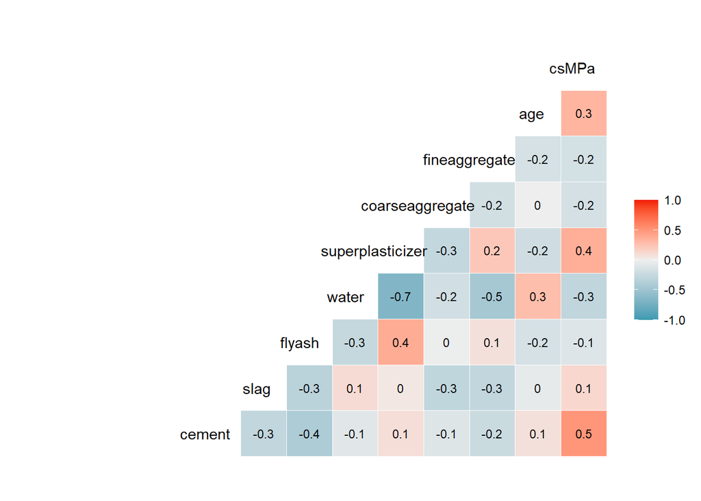

So it appears that there is a positive correlation between cement, superplasticizer, and age. There is a negative correlation with water. There is also an interesting negative correlation between water and superplasticizer, which makes perfect sense. Superplasticizer is usually added in order to [**reduce the required water content**](https://www.engr.psu.edu/ce/courses/ce584/concrete/library/materials/Admixture/AdmixturesMain.htm). Excess water can harm the strength of concrete.

Looking at the data above, cement content seems like a fairly strong predictor. Lets visualize that with a scatter plot:

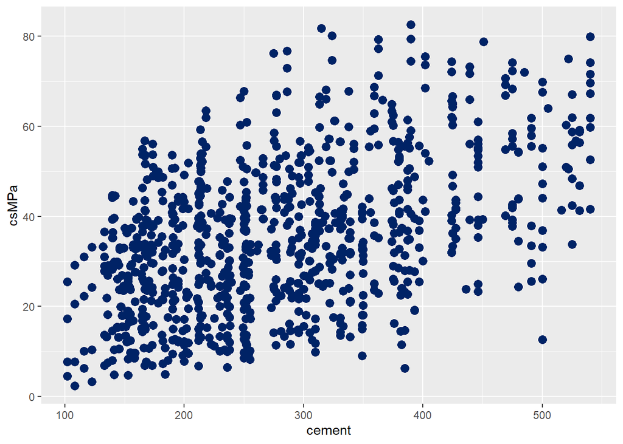

There is lots of scatter, but there is a general upward sloping response.

## Model Planning

Because there appears to be some correlation between individual ingredients and compressive strength, I will use linear regression in order to model the behavior of concrete. I will split the data set 80 / 20 into training and test data sets, and then try to determine how well the prediction works.

**The Mathematics Behind Linear Regression**

Simplified, linear regression is a supervised learning method that tries to show the relationship between variables by fitting a straight line. So for the regression of a variable $\ Y$ (in our example, concrete compressive strength) on variable $\ X$ the formula would be:

$$Y_{i} = \beta_0 + \beta_1x_i + \epsilon_i \;\;\; i=1,...,n$$

This is simply solving for the slope and intercept for the given variables. The intercept is the point where the line intercepts the y-axis, and the slope is the increase in $\ Y$ per unit change of $\ X$. The residual term, $\ \epsilon_i$ represents the error from the predicted line to the actual data.

The actual fitting of the line is done through the least squares method. The goal is to minimize the sum of the squared residuals, which follows the form
$$\sum_{i=1}^n (y^{ref}_{i}-y^{pred}_{i})^{2}$$

## Model Building

First, the data is split into the aforementioned groups to aid training, and then the linear regression model will be generated.

The summary of that model shows a few interesting things:

```
##
## Call:
## lm(formula = csMPa ~ cement, data = trainDat)
##
## Residuals:
##     Min      1Q  Median      3Q     Max
## -40.199 -10.959  -0.599   9.996  43.414
##
## Coefficients:
##              Estimate Std. Error t value Pr(>|t|)
## (Intercept) 13.641275   1.439094   9.479   <2e-16 ***
## cement       0.078395   0.004788  16.374   <2e-16 ***
## ---
## Signif. codes:  0 '***' 0.001 '**' 0.01 '*' 0.05 '.' 0.1 ' ' 1
##
## Residual standard error: 14.51 on 824 degrees of freedom
## Multiple R-squared:  0.2455, Adjusted R-squared:  0.2446
## F-statistic: 268.1 on 1 and 824 DF,  p-value: < 2.2e-16
```

The min and max residuals are very high. $\ +/-$ 40MPa on a material that maxes out around 80 MPa in strength is not great. Also, an $\ R^2$ .24 is nothing to call home about. So the results aren’t excellent, but they still show some correlation that might be useful.

## Communicate Results

From here, lets look at a the regression line from the model fit to the data:

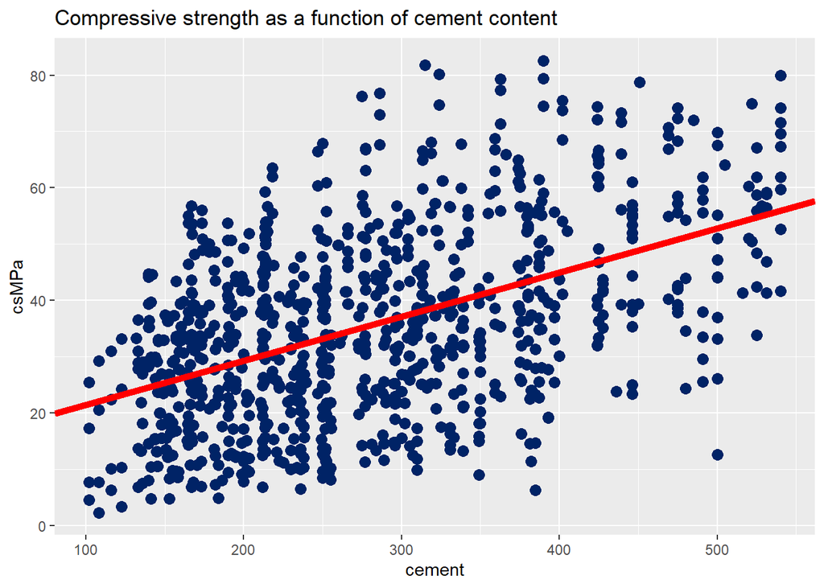

Lets look at the predicted strength versus the reference strength for the test data set, using the model we developed with the training set. We’ll add error bars representing the confidence intervals.

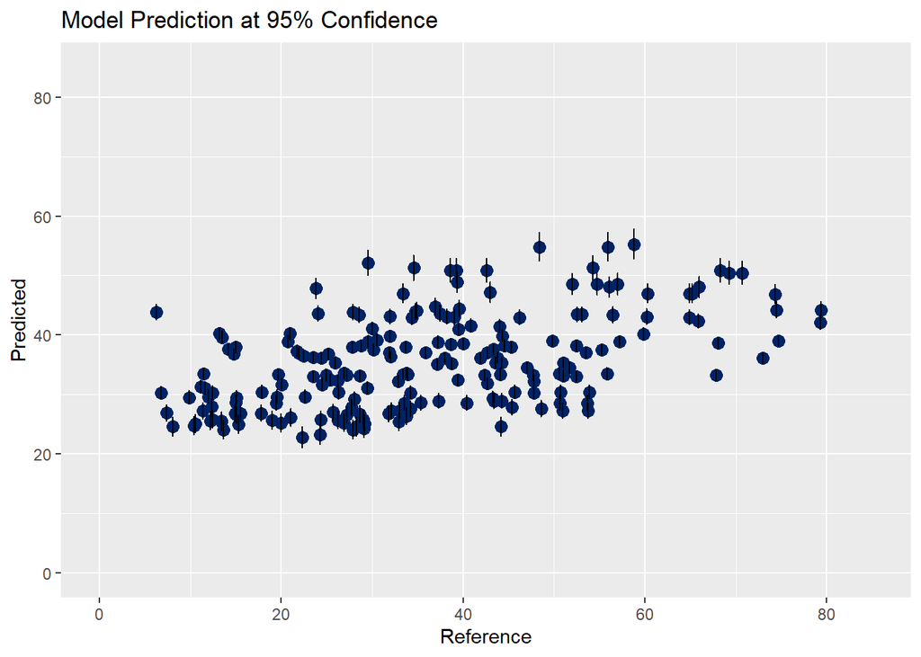

It does show a positive correlation, but again from the summary above, its not great. How do the prediction intervals look for the same data?

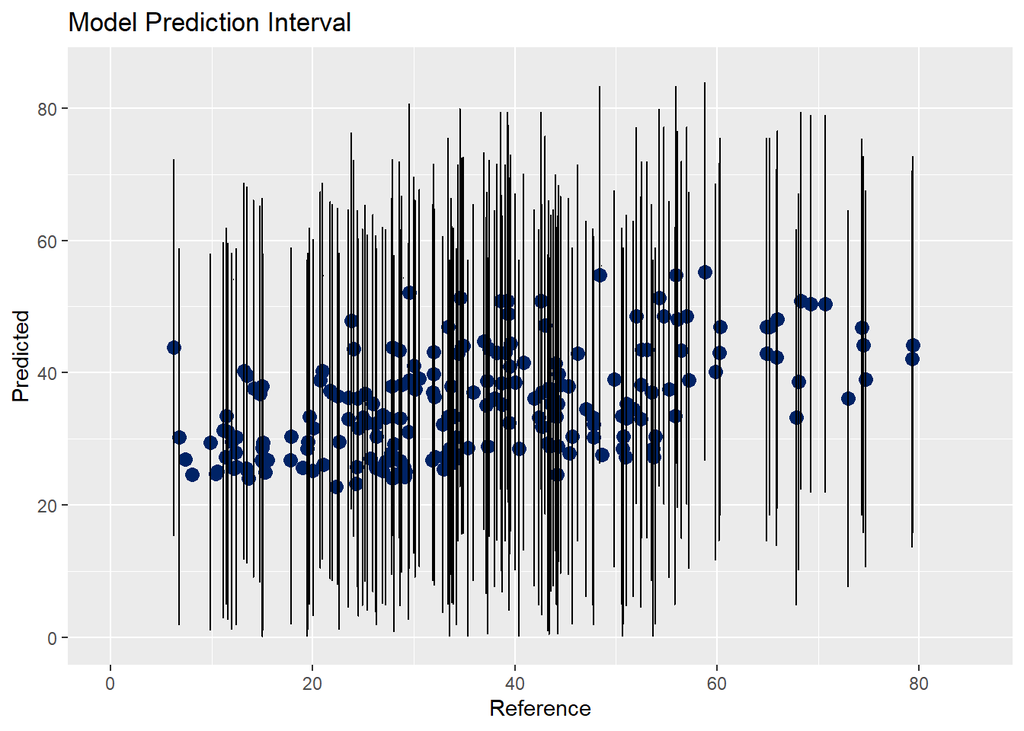

This backs up the data provided by the summary: the prediction interval is pretty big, making this a less than perfect model. That said, given it can take up to a year to empirically generate data, there still may be some value in this model.

Lets look over some of the quality metrics for this model:

Predicted residual sum of squares $\ = \sum_{i=1}^n (y^{ref}_{i}-y^{pred}_{i})^{2}$ = 42537.97

Root mean squared error of prediction $\ = \sqrt{\frac{1}{n_{T}}\sum_{1}^{n_{T}} (y_{i}^{ref} - y_{i}^{pred})^{2}}$ = 14.4402

Total sum of squares $\ = \sum_{i=1}^{n} (y^{ref}_{i}-y^{mean}_{i})^{2}$ = 57171.89

$R^{2}$ = $\ = 1 - \frac{PRESS}{SST}$ = 0.2559636

As a whole, using a cement content to predict compressive strength works, but does not work very well. If we start to take other ingredients into account, things start to look much clearer.

## A Better Approach

Referring back to the correlation plot, there are some other variables that appear to have a relationship with compressive strength. So at this point, we’ll build a linear regression model, feeding the algortithm multiple variables.

Since cement, age, and superplasticizer seem to have a positive effect, we’ll start there.

```
##
## Call:
## lm(formula = csMPa ~ cement + superplasticizer + age, data = trainDat[,
##     c(1, 5, 8, 9)])
##
## Residuals:
##     Min      1Q  Median      3Q     Max
## -33.705  -8.136  -0.656   7.745  45.656
##
## Coefficients:
##                  Estimate Std. Error t value Pr(>|t|)
## (Intercept)      5.112227   1.300508   3.931 9.17e-05 ***
## cement           0.068999   0.004067  16.965  < 2e-16 ***
## superplasticizer 1.122689   0.074736  15.022  < 2e-16 ***
## age              0.093699   0.006835  13.709  < 2e-16 ***
## ---
## Signif. codes:  0 '***' 0.001 '**' 0.01 '*' 0.05 '.' 0.1 ' ' 1
##
## Residual standard error: 12.23 on 822 degrees of freedom
## Multiple R-squared:  0.4656, Adjusted R-squared:  0.4637
## F-statistic: 238.8 on 3 and 822 DF,  p-value: < 2.2e-16
```

So by adding those two more variables to the model, we effectively doubled our $\ r^2$ value. That is not bad for minimal effort. In the provided Shiny application, the user can add as many variables as they please to see the effect of doing so.

Lets look at the predicted value chart with confidence and prediction interval bars:

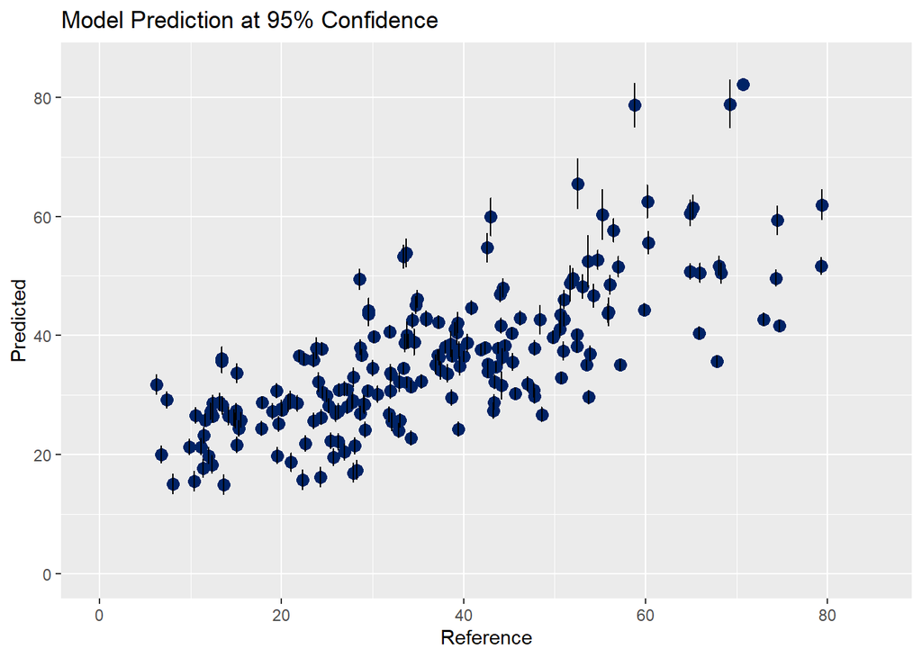

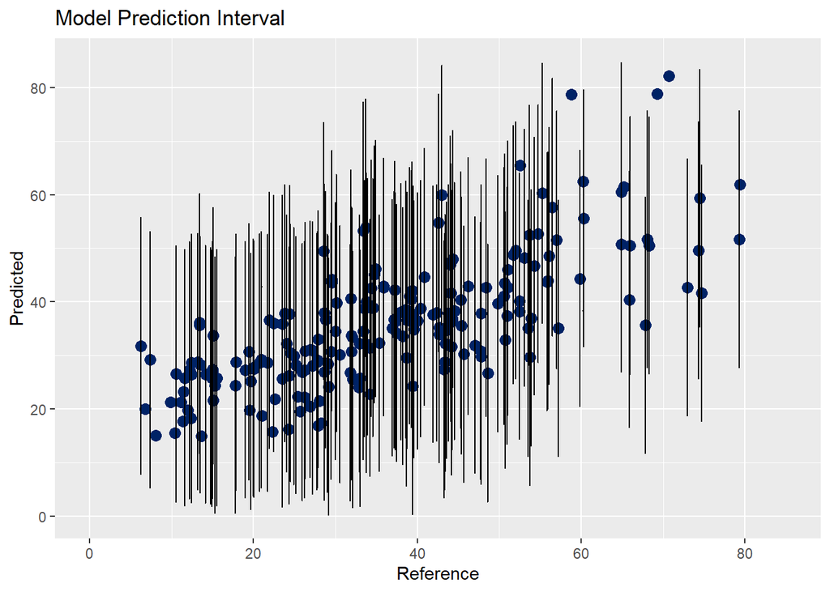

Predicted residual sum of squares $\ = \sum_{i=1}^n (y^{ref}_{i}-y^{pred}_{i})^{2}$ = 26035.39

Root mean squared error of prediction $\ = \sqrt{\frac{1}{n_{T}}\sum_{1}^{n_{T}} (y_{i}^{ref} - y_{i}^{pred})^{2}}$ = 11.2971

Total sum of squares $\ = \sum_{i=1}^{n} (y^{ref}_{i}-y^{mean}_{i})^{2}$ = 57171.89

$R^{2}$ = $\ = 1 - \frac{PRESS}{SST}$ = 0.544612

## Operationalize

**Data wrap up**

The multivariate linear regression model is better than the univariate method, but still leaves some performance on the table. Browsing Kaggle, it appears that this data set is a good candidate for neural network methods. At this point in the project, that would be the logical next step.

**Shiny Deployment**

The work performed here has now been ported to a Shiny application. The math for generating a linear regression model in R-studio is very straightforward, so the bulk of the development was done on making sure the Shiny UI handled inputs correctly. There were several test cases run for on the multivariate app in order to make sure if the user selected a single variable the application would not crash. There was also some effort in making sure the UI flowed logically from left to right and top to bottom while not being an eyesore. The Shiny Router application from [**Appsilon**](https://appsilon.com/shiny-router-020/) helped tremendously in this regard.

## Notes and Citations

1. [**Linear Regression Basics, Yale**](http://www.stat.yale.edu/Courses/1997-98/101/linreg.htm)
2. [**Yeh Concrete Data**](https://www.kaggle.com/maajdl/yeh-concret-data)
3. [**Shiny Cheatsheet**](https://shiny.rstudio.com/images/shiny-cheatsheet.pdf)
4. [**Cement.org Concrete Basics**](https://www.cement.org/cement-concrete/cement-and-concrete-basics-faqs)
5. [**Dr. Narahara Chari Dingari, Lab 7 Linear Regression**](https://canvas.wpi.edu/courses/21592/files/2904353?module_item_id=442213)